# Differential Expression

2018-05-19

```r
# Last modified 2018-05-10
bcbioRNASeq::prepareRNASeqTemplate()
source("_setup.R")

# Directory paths ==============================================================
invisible(mapply(
    FUN = dir.create,
    path = c(params$data_dir, params$results_dir),
    MoreArgs = list(showWarnings = FALSE, recursive = TRUE)
))

# Load object ==================================================================
bcb_name <- load(params$bcb_file)
bcb <- get(bcb_name, inherits = FALSE)
stopifnot(is(bcb, "bcbioRNASeq"))
invisible(validObject(bcb))
```

# Overview

```r
> dds <- as(bcb, "DESeqDataSet")
> design(dds) <- params$design
> dds <- DESeq(dds)
```

```
## found already estimated dispersions, replacing these
```

```r
> # Alternatively, can use `rlog()`
> rld <- varianceStabilizingTransformation(dds)
```

# Alpha level (FDR) cutoffs

Let’s take a look at the number of genes we get with different false discovery rate (FDR) cutoffs. These tests subset *P* values that have been multiple test corrected using the Benjamini Hochberg (BH) method (Benjamini and Hochberg 1995).

```r
> alphaSummary(dds)
```

|  | 0.1 | 0.05 | 0.01 | 0.001 | 1e-06 |
| --- | --- | --- | --- | --- | --- |
| LFC > 0 (up) | LFC > 0 (up) : 179, 0.61% | LFC > 0 (up) : 142, 0.48% | LFC > 0 (up) : 93, 0.32% | LFC > 0 (up) : 58, 0.2% | LFC > 0 (up) : 25, 0.085% |
| LFC < 0 (down) | LFC < 0 (down) : 140, 0.48% | LFC < 0 (down) : 104, 0.35% | LFC < 0 (down) : 58, 0.2% | LFC < 0 (down) : 38, 0.13% | LFC < 0 (down) : 15, 0.051% |
| outliers | outliers [1] : 0, 0% | outliers [1] : 0, 0% | outliers [1] : 0, 0% | outliers [1] : 0, 0% | outliers [1] : 0, 0% |
| low counts | low counts [2] : 11599, 39% | low counts [2] : 11046, 38% | low counts [2] : 11046, 38% | low counts [2] : 10494, 36% | low counts [2] : 16570, 56% |
| cutoff | (mean count < 7) | (mean count < 6) | (mean count < 6) | (mean count < 5) | (mean count < 74) |

# Results

```r
> # help("results", "DESeq2")
> # For contrast argument as character vector:
> #   1. Design matrix factor of interest.
> #   2. Numerator for LFC (expt).
> #   3. Denominator for LFC (control).
> res_unshrunken <- results(
+     object = dds,
+     contrast = params$contrast,
+     alpha = params$alpha
+ )
>
> # DESeqResults with shrunken log2 fold changes (LFC)
> # help("lfcShrink", "DESeq2")
> # Use the correct `coef` number to modify from `resultsNames(dds)`
> res_shrunken <- lfcShrink(
+     dds = dds,
+     coef = 2,
+     res = res_unshrunken
+ )
>
> # Use shrunken LFC values by default
> res <- res_shrunken
> saveData(res, res_shrunken, res_unshrunken, dir = params$data_dir)
```

```
## Saving res.rda, res_shrunken.rda, res_unshrunken.rda to /home/travis/build/hbc/bcbio_rnaseq_output_example/report/data
```

We performed the analysis using a BH adjusted *P* value cutoff of 0.01 and a log fold-change (LFC) ratio cutoff of 0.

# Plots

## Mean average (MA)

An MA plot compares transformed counts on `M` (log ratio) and `A` (mean average) scales (Yang et al. 2002).

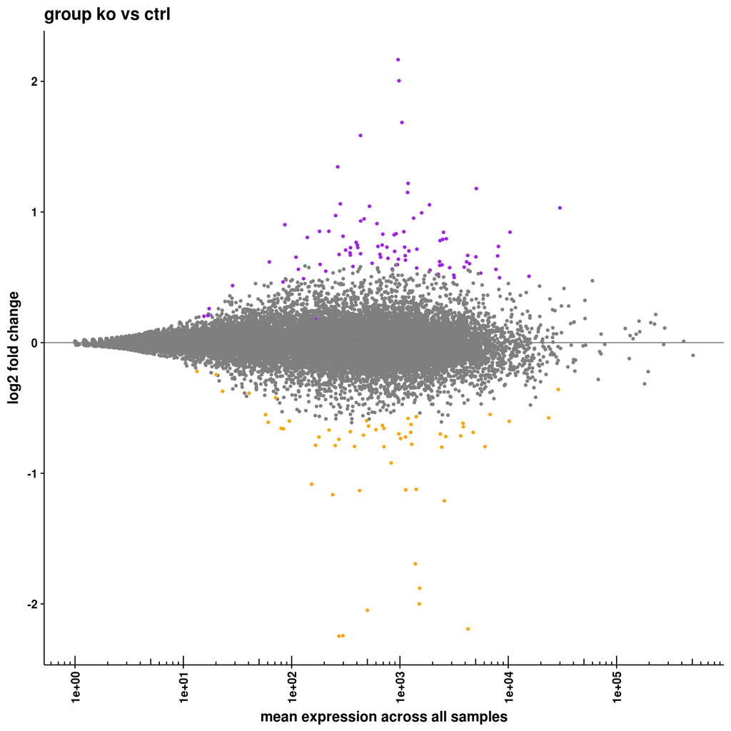

```r
> plotMeanAverage(res)
```

```r
> # Alternate plot
> # DESeq2::plotMA(res)
```

## Volcano

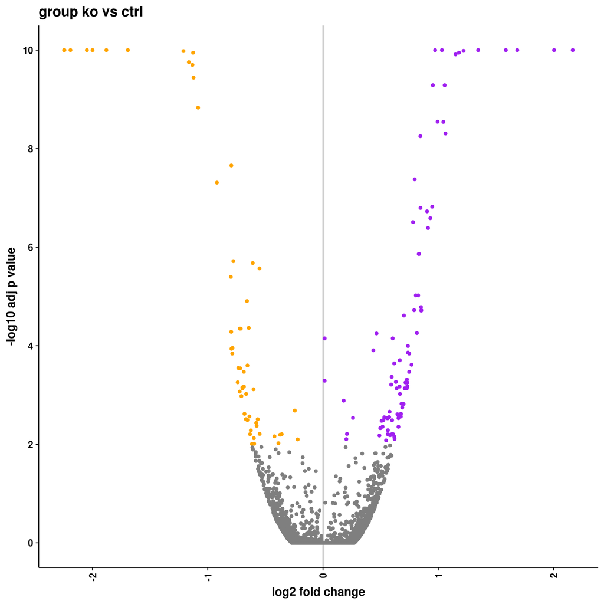

```r
> plotVolcano(res, lfcThreshold = params$lfc_threshold)
```

## Heatmap

This plot shows only differentially expressed genes on a per-sample basis. We have scaled the data by row and used the `ward.D2` method for clustering (Ward 1963).

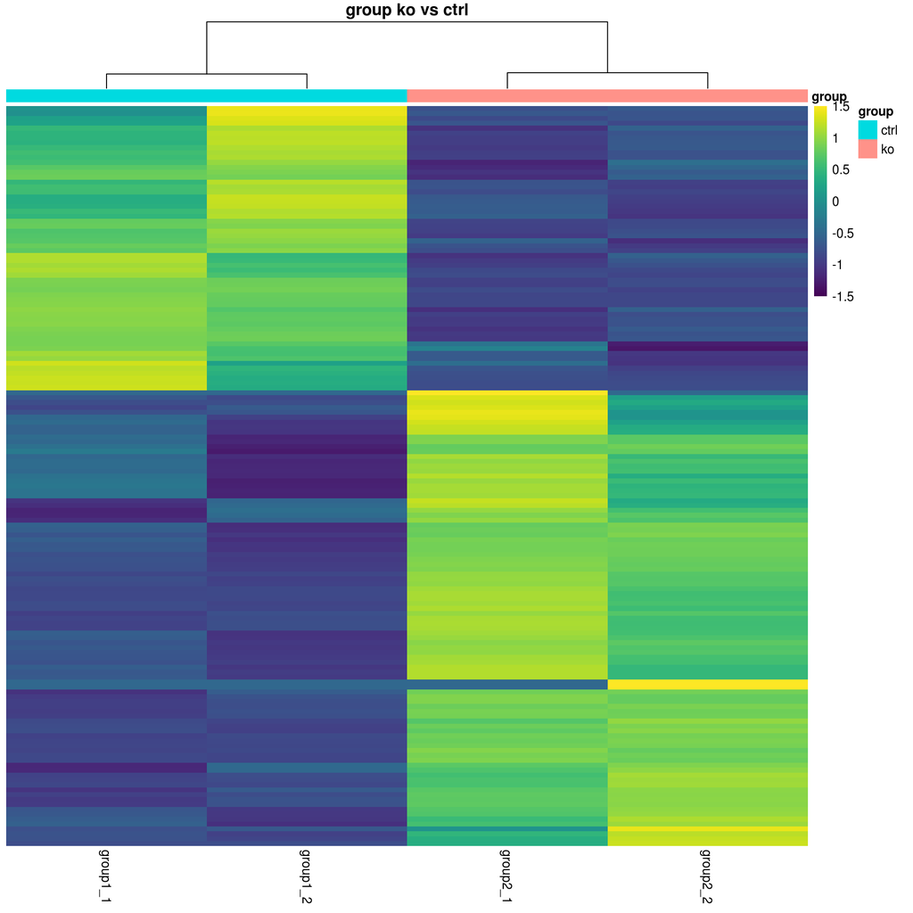

```r
> # help("pheatmap", "pheatmap")
> plotDEGHeatmap(
+     results = res,
+     counts = rld,
+     clusteringMethod = "ward.D2",
+     scale = "row"
+ )
```

## PCA

```
## Plotting PCA using 151 genes
```

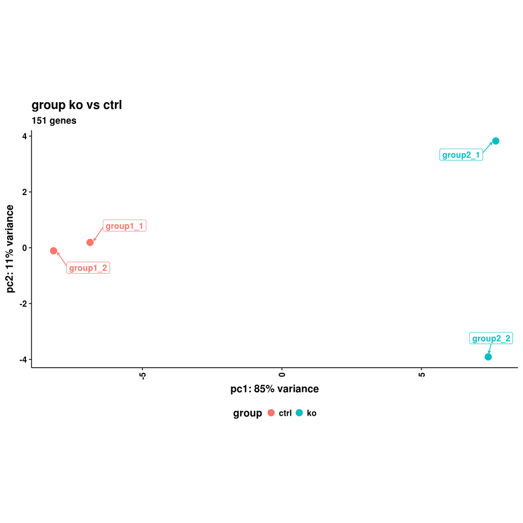

```r
> plotDEGPCA(
+     results = res,
+     counts = rld,
+     label = TRUE
+ )
```

# Results tables

```r
> res_tbl <- resultsTables(
+     results = res,
+     counts = dds,
+     lfcThreshold = params$lfc_threshold,
+     write = TRUE,
+     summary = TRUE,
+     headerLevel = 2,
+     dir = params$results_dir,
+     dropboxDir = params$dropbox_dir
+ )
```

## group ko vs ctrl

### Summary statistics

- 47729 genes in counts matrix
- Base mean > 0: 29451 genes (non-zero)
- Base mean > 1: 23567 genes
- Alpha: 0.01
- LFC threshold: 0
- DEG pass alpha: 151 genes
- DEG LFC up: 93 genes
- DEG LFC down: 58 genes

```
## Writing group_ko_vs_ctrl_all.csv.gz, group_ko_vs_ctrl_deg.csv.gz, group_ko_vs_ctrl_deg_lfc_up.csv.gz, group_ko_vs_ctrl_deg_lfc_down.csv.gz to /home/travis/build/hbc/bcbio_rnaseq_output_example/report
```

### Results tables

- `group_ko_vs_ctrl_all.csv.gz`: All genes, sorted by Ensembl identifier.
- `group_ko_vs_ctrl_deg.csv.gz`: Genes that pass the alpha (FDR) cutoff.
- `group_ko_vs_ctrl_deg_lfc_up.csv.gz`: Upregulated DEG; positive log2 fold change.
- `group_ko_vs_ctrl_deg_lfc_down.csv.gz`: Downregulated DEG; negative log2 fold change.

```r
> saveData(res_tbl, dir = params$data_dir)
```

```
## Saving res_tbl.rda to /home/travis/build/hbc/bcbio_rnaseq_output_example/report/data
```

Differentially expressed gene (DEG) tables are sorted by BH-adjusted P value, and contain the following columns:

- `baseMean`: Mean of the normalized counts per gene for all samples.
- `log2FoldChange`: log2 fold change.
- `lfcSE`: log2 standard error.
- `stat`: Wald statistic.
- `pvalue`: Walt test *P* value.
- `padj`: BH adjusted Wald test *P* value (corrected for multiple comparisons; aka FDR).

## Top tables

```r
> topTables(res_tbl)
```

group ko vs ctrl (upregulated)

| geneID | geneName | geneBiotype | baseMean | lfc | padj | description |
| --- | --- | --- | --- | --- | --- | --- |
| ENSMUSG00000020038 | Cry1 | protein_coding | 962 | 2.1664 | 4.36e-51 | Cryptochrome-1 |
| ENSMUSG00000026442 | Nfasc | protein_coding | 980 | 2.0047 | 8.45e-40 | Neurofascin |
| ENSMUSG00000026077 | Npas2 | protein_coding | 1043 | 1.6856 | 5.01e-25 | neuronal PAS domain protein 2 |
| ENSMUSG00000029757 | Dync1i1 | protein_coding | 432 | 1.5861 | 1.40e-21 | Cytoplasmic dynein 1 intermediate chain 1 |
| ENSMUSG00000027712 | Anxa5 | protein_coding | 30000 | 1.0318 | 9.00e-15 | Annexin A5 |
| ENSMUSG00000029108 | Pcdh7 | protein_coding | 266 | 1.3461 | 9.35e-15 | protocadherin 7 |
| ENSMUSG00000102802 | Mgam2-ps | transcribed_unprocessed_pseudogene | 255 | 0.9727 | 1.94e-13 | maltase-glucoamylase 2, pseudogene |
| ENSMUSG00000022790 | Igsf11 | protein_coding | 1189 | 1.2195 | 3.57e-12 | Immunoglobulin superfamily member 11 |
| ENSMUSG00000053279 | Aldh1a1 | protein_coding | 5065 | 1.1795 | 1.27e-11 | Retinal dehydrogenase 1 |
| ENSMUSG00000023959 | Clic5 | protein_coding | 1175 | 1.1497 | 2.22e-11 | Chloride intracellular channel protein 5 |
| ENSMUSG00000028150 | Rorc | protein_coding | 1336 | 0.9531 | 4.15e-10 | Nuclear receptor ROR-gamma |
| ENSMUSG00000050447 | Lypd6 | protein_coding | 1872 | 1.0553 | 4.15e-10 | Ly6/PLAUR domain-containing protein 6 |
| ENSMUSG00000051359 | Ncald | protein_coding | 1588 | 0.9939 | 2.74e-09 | Neurocalcin-delta |
| ENSMUSG00000060044 | Tmem26 | protein_coding | 523 | 1.0440 | 2.76e-09 | Transmembrane protein 26 |
| ENSMUSG00000062760 | 1810041L15Rik | protein_coding | 282 | 1.0624 | 4.82e-09 | Mus musculus RIKEN cDNA 1810041L15 (1810041L15Rik), transcript variant 2, mRNA. |
| ENSMUSG00000028214 | Gem | protein_coding | 2525 | 0.8447 | 5.49e-09 | GTP-binding protein GEM |
| ENSMUSG00000004035 | Gstm7 | protein_coding | 2676 | 0.7955 | 4.18e-08 | Glutathione S-transferase Mu 7 |
| ENSMUSG00000027335 | Adra1d | protein_coding | 467 | 0.9476 | 1.51e-07 | adrenoceptor alpha 1D |
| ENSMUSG00000004098 | Col5a3 | protein_coding | 10375 | 0.8456 | 1.59e-07 | collagen, type V, alpha 3 |
| ENSMUSG00000045094 | Arhgef37 | protein_coding | 87 | 0.9027 | 1.87e-07 | Rho guanine nucleotide exchange factor 37 |
| ENSMUSG00000037946 | Fgd3 | protein_coding | 434 | 0.9311 | 2.58e-07 | FYVE, RhoGEF and PH domain containing 3 |
| ENSMUSG00000030630 | Fah | protein_coding | 2345 | 0.7811 | 3.10e-07 | Fumarylacetoacetase |
| ENSMUSG00000039208 | Metrnl | protein_coding | 613 | 0.9110 | 4.08e-07 | Meteorin-like protein |
| ENSMUSG00000023067 | Cdkn1a | protein_coding | 695 | 0.8304 | 1.37e-06 | Cyclin-dependent kinase inhibitor 1 |
| ENSMUSG00000056749 | Nfil3 | protein_coding | 922 | 0.8340 | 1.37e-06 | Nuclear factor interleukin-3-regulated protein |
| ENSMUSG00000037705 | Tecta | protein_coding | 140 | 0.8054 | 9.51e-06 | tectorin alpha |
| ENSMUSG00000063659 | Zbtb18 | protein_coding | 883 | 0.8256 | 9.51e-06 | zinc finger and BTB domain containing 18 |
| ENSMUSG00000028179 | Cth | protein_coding | 1086 | 0.8493 | 1.64e-05 | Cystathionine gamma-lyase |
| ENSMUSG00000031380 | Vegfd | protein_coding | 2479 | 0.7906 | 1.90e-05 | vascular endothelial growth factor D |
| ENSMUSG00000055305 | Zfp93 | protein_coding | 221 | 0.8526 | 1.90e-05 | zinc finger protein 93 |
| ENSMUSG00000028359 | Orm3 | protein_coding | 181 | 0.8518 | 1.94e-05 | orosomucoid 3 |
| ENSMUSG00000022500 | Litaf | protein_coding | 1209 | 0.7022 | 2.44e-05 | Lipopolysaccharide-induced tumor necrosis factor-alpha factor homolog |
| ENSMUSG00000031543 | Ank1 | protein_coding | 298 | 0.8144 | 5.53e-05 | Ankyrin-1 |
| ENSMUSG00000035270 | Impg2 | protein_coding | 83 | 0.4646 | 5.63e-05 | Interphotoreceptor matrix proteoglycan 2 |
| ENSMUSG00000034158 | Lrrc58 | protein_coding | 4388 | 0.6048 | 7.08e-05 | Leucine-rich repeat-containing protein 58 |
| ENSMUSG00000083833 | Gm13841 | processed_pseudogene | 409 | 0.0139 | 7.11e-05 | predicted gene 13841 |
| ENSMUSG00000094497 | Gm8210 | processed_pseudogene | 409 | 0.0139 | 7.11e-05 | predicted pseudogene 8210 |
| ENSMUSG00000028760 | Eif4g3 | protein_coding | 8111 | 0.7366 | 1.01e-04 | Mus musculus eukaryotic translation initiation factor 4 gamma, 3 (Eif4g3), transcript variant 4, mRNA. |
| ENSMUSG00000030735 | Gm9755 | processed_pseudogene | 28 | 0.4367 | 1.24e-04 | predicted pseudogene 9755 |
| ENSMUSG00000000628 | Hk2 | protein_coding | 626 | 0.7368 | 1.38e-04 | Hexokinase-2 |
| ENSMUSG00000036545 | Adamts2 | protein_coding | 404 | 0.7479 | 1.44e-04 | A disintegrin and metalloproteinase with thrombospondin motifs 2 |
| ENSMUSG00000030583 | Sipa1l3 | protein_coding | 1117 | 0.6661 | 1.97e-04 | signal-induced proliferation-associated 1 like 3 |
| ENSMUSG00000097836 | Gm26903 | antisense | 62 | 0.6177 | 2.28e-04 | predicted gene, 26903 |
| ENSMUSG00000099009 | Rdh16f1 | protein_coding | 394 | 0.7676 | 2.43e-04 | NULL |
| ENSMUSG00000052852 | Reep1 | protein_coding | 685 | 0.7474 | 3.39e-04 | Receptor expression-enhancing protein 1 |
| ENSMUSG00000006611 | Hfe | protein_coding | 2447 | 0.5958 | 4.28e-04 | Hereditary hemochromatosis protein homolog |
| ENSMUSG00000001334 | Fndc5 | protein_coding | 408 | 0.7281 | 4.85e-04 | Fibronectin type III domain-containing protein 5 Irisin |
| ENSMUSG00000055298 | Ctsj | protein_coding | 92 | 0.0139 | 5.13e-04 | cathepsin J |
| ENSMUSG00000029385 | Ccng2 | protein_coding | 1125 | 0.6321 | 5.41e-04 | Cyclin-G2 |
| ENSMUSG00000025321 | Itgb8 | protein_coding | 1104 | 0.7315 | 5.58e-04 | integrin subunit beta 8 |

group ko vs ctrl (downregulated)

| geneID | geneName | geneBiotype | baseMean | lfc | padj | description |
| --- | --- | --- | --- | --- | --- | --- |
| ENSMUSG00000052974 | Cyp2f2 | protein_coding | 4250 | -2.191 | 2.40e-48 | Cytochrome P450 2F2 |
| ENSMUSG00000059824 | Dbp | protein_coding | 1509 | -2.000 | 9.65e-46 | D site-binding protein |
| ENSMUSG00000066258 | Trim12a | protein_coding | 298 | -2.243 | 2.05e-40 | Tripartite motif-containing protein 12A |
| ENSMUSG00000028358 | Zfp618 | protein_coding | 500 | -2.049 | 1.28e-38 | zinc finger protein 618 |
| ENSMUSG00000057596 | Trim30d | protein_coding | 274 | -2.246 | 1.28e-38 | tripartite motif-containing 30D |
| ENSMUSG00000021775 | Nr1d2 | protein_coding | 1518 | -1.880 | 2.32e-36 | nuclear receptor subfamily 1, group D, member 2 |
| ENSMUSG00000020889 | Nr1d1 | protein_coding | 1385 | -1.693 | 1.56e-25 | Nuclear receptor subfamily 1 group D member 1 |
| ENSMUSG00000032281 | Acsbg1 | protein_coding | 2568 | -1.211 | 4.72e-12 | acyl-CoA synthetase bubblegum family member 1 |
| ENSMUSG00000049892 | Rasd1 | protein_coding | 1131 | -1.127 | 1.28e-11 | Dexamethasone-induced Ras-related protein 1 |
| ENSMUSG00000040896 | Kcnd3 | protein_coding | 240 | -1.164 | 7.53e-11 | potassium voltage-gated channel, Shal-related family, member 3 |
| ENSMUSG00000001864 | Aif1l | protein_coding | 424 | -1.132 | 9.95e-11 | Allograft inflammatory factor 1-like |
| ENSMUSG00000017969 | Ptgis | protein_coding | 1412 | -1.123 | 2.62e-10 | prostaglandin I2 (prostacyclin) synthase |
| ENSMUSG00000045868 | Gvin1 | protein_coding | 153 | -1.084 | 1.37e-09 | NULL |
| ENSMUSG00000036856 | Wnt4 | protein_coding | 6100 | -0.795 | 2.18e-08 | wingless-type MMTV integration site family, member 4 |
| ENSMUSG00000035357 | Pdzrn3 | protein_coding | 829 | -0.921 | 4.88e-08 | E3 ubiquitin-protein ligase PDZRN3 |
| ENSMUSG00000036502 | Tmem255a | protein_coding | 1283 | -0.778 | 1.92e-06 | Transmembrane protein 255A |
| ENSMUSG00000029306 | Ibsp | protein_coding | 61 | -0.610 | 2.10e-06 | Bone sialoprotein 2 |
| ENSMUSG00000096972 | Gm26883 | lincRNA | 57 | -0.551 | 2.69e-06 | predicted gene, 26883 |
| ENSMUSG00000069094 | Pde7a | protein_coding | 2428 | -0.800 | 4.00e-06 | High affinity cAMP-specific 3’,5’-cyclic phosphodiesterase 7A |
| ENSMUSG00000007682 | Dio2 | protein_coding | 84 | -0.660 | 1.24e-05 | Type II iodothyronine deiodinase |
| ENSMUSG00000022419 | Deptor | protein_coding | 3848 | -0.644 | 4.34e-05 | DEP domain-containing mTOR-interacting protein |
| ENSMUSG00000024360 | Etf1 | protein_coding | 3640 | -0.713 | 4.50e-05 | Eukaryotic peptide chain release factor subunit 1 |
| ENSMUSG00000031376 | Atp2b3 | protein_coding | 1127 | -0.722 | 4.50e-05 | ATPase, Ca++ transporting, plasma membrane 3 |
| ENSMUSG00000035686 | Thrsp | protein_coding | 712 | -0.796 | 5.22e-05 | thyroid hormone responsive |
| ENSMUSG00000030256 | Bhlhe41 | protein_coding | 166 | -0.785 | 1.11e-04 | Class E basic helix-loop-helix protein 41 |
| ENSMUSG00000002633 | Shh | protein_coding | 381 | -0.795 | 1.15e-04 | Sonic hedgehog protein Sonic hedgehog protein N-product |
| ENSMUSG00000001665 | Gstt3 | protein_coding | 252 | -0.787 | 1.44e-04 | Mus musculus glutathione S-transferase, theta 3 (Gstt3), transcript variant 2, mRNA. |
| ENSMUSG00000060441 | Trim5 | protein_coding | 80 | -0.656 | 2.51e-04 | NULL |
| ENSMUSG00000027227 | Sord | protein_coding | 1014 | -0.734 | 2.83e-04 | sorbitol dehydrogenase |
| ENSMUSG00000031824 | 6430548M08Rik | protein_coding | 2650 | -0.719 | 2.87e-04 | Uncharacterized protein KIAA0513 |
| ENSMUSG00000031451 | Gas6 | protein_coding | 4742 | -0.687 | 3.38e-04 | Growth arrest-specific protein 6 |
| ENSMUSG00000026527 | Rgs7 | protein_coding | 273 | -0.740 | 5.52e-04 | regulator of G protein signaling 7 |
| ENSMUSG00000025511 | Tspan4 | protein_coding | 1258 | -0.686 | 6.73e-04 | tetraspanin 4 |
| ENSMUSG00000023019 | Gpd1 | protein_coding | 2359 | -0.700 | 7.01e-04 | glycerol-3-phosphate dehydrogenase 1 (soluble) |
| ENSMUSG00000002324 | Rec8 | protein_coding | 976 | -0.698 | 7.31e-04 | Meiotic recombination |
| ENSMUSG00000038393 | Txnip | protein_coding | 10215 | -0.603 | 7.64e-04 | thioredoxin interacting protein |
| ENSMUSG00000027875 | Hmgcs2 | protein_coding | 179 | -0.723 | 8.52e-04 | Hydroxymethylglutaryl-CoA synthase, mitochondrial |
| ENSMUSG00000055368 | Slc6a2 | protein_coding | 600 | -0.667 | 9.50e-04 | solute carrier family 6 (neurotransmitter transporter, noradrenalin), member 2 |
| ENSMUSG00000002289 | Angptl4 | protein_coding | 461 | -0.708 | 1.05e-03 | Angiopoietin-related protein 4 |
| ENSMUSG00000066068 | Gm13611 | processed_pseudogene | 20 | -0.245 | 2.07e-03 | predicted gene 13611 |
| ENSMUSG00000016386 | Mpped2 | protein_coding | 348 | -0.681 | 2.41e-03 | Metallophosphoesterase MPPED2 |
| ENSMUSG00000035211 | Xrra1 | protein_coding | 513 | -0.639 | 2.72e-03 | X-ray radiation resistance associated 1 |
| ENSMUSG00000024731 | Ms4a10 | protein_coding | 222 | -0.669 | 3.09e-03 | Membrane-spanning 4-domains subfamily A member 10 |
| ENSMUSG00000051855 | Mest | protein_coding | 1415 | -0.567 | 3.10e-03 | Mesoderm-specific transcript protein |
| ENSMUSG00000007097 | Atp1a2 | protein_coding | 710 | -0.656 | 3.22e-03 | Sodium/potassium-transporting ATPase subunit alpha-2 |
| ENSMUSG00000031217 | Efnb1 | protein_coding | 1188 | -0.579 | 3.67e-03 | Ephrin-B1 |
| ENSMUSG00000049265 | Kcnk3 | protein_coding | 23606 | -0.576 | 4.22e-03 | Potassium channel subfamily K member 3 |
| ENSMUSG00000026678 | Rgs5 | protein_coding | 1266 | -0.626 | 5.23e-03 | regulator of G-protein signaling 5 |
| ENSMUSG00000005268 | Prlr | protein_coding | 6801 | -0.550 | 6.15e-03 | prolactin receptor |
| ENSMUSG00000024164 | C3 | protein_coding | 28947 | -0.358 | 6.23e-03 | Complement C3 Complement C3 beta chain C3-beta-c Complement C3 alpha chain C3a anaphylatoxin Acylation stimulating protein Complement C3b alpha’ chain Complement C3c alpha’ chain fragment 1 Complement… |

# Methods

RNA-seq counts were generated by [bcbio](https://github.com/chapmanb/bcbio-nextgen) and bcbioRNASeq using salmon (Patro et al. 2017). Counts were imported into [R](https://www.r-project.org) using [tximport](https://bioconductor.org/packages/release/bioc/html/tximport.html) (Soneson, Love, and Robinson 2016) and [DESeq2](https://bioconductor.org/packages/release/bioc/html/DESeq2.html) (Love, Huber, and Anders 2014). Gene annotations were obtained from [Ensembl](https://www.ensembl.org). Plots were generated by [ggplot2](http://ggplot2.org) (Wickham 2009). Heatmaps were generated by [pheatmap](https://cran.r-project.org/web/packages/pheatmap/index.html) (Kolde 2015).

# R session information

```r
> markdownHeader("YAML params", level = 2)
```

## YAML params

```r
> print(params)
```

```
## $alpha
## [1] 0.01
##
## $lfc_threshold
## [1] 0
##
## $dropbox_dir
## NULL
##
## $bcb_file
##                                                                      bcb
## "/home/travis/build/hbc/bcbio_rnaseq_output_example/report/data/bcb.rda"
##
## $design
## ~group
## <environment: 0x19e95758>
##
## $contrast
## [1] "group" "ctrl"  "ko"
##
## $data_dir
## [1] "data"
##
## $results_dir
## [1] "/home/travis/build/hbc/bcbio_rnaseq_output_example/report"
```

```r
> markdownHeader("`_setup.R`", level = 2)
```

## `_setup.R`

```r
> readr::read_lines("_setup.R") %>% writeLines()
```

```
## library(bcbioRNASeq)
## library(DESeq2)
## library(DEGreport)
##
## library(knitr)
## library(tidyverse)
##
## # Set seed for reproducibility
## set.seed(1454944673L)
##
## opts_chunk[["set"]](
##     autodep = TRUE,
##     bootstrap.show.code = FALSE,
##     cache = TRUE,
##     cache.lazy = TRUE,
##     dev = c("png", "pdf"),
##     error = TRUE,
##     fig.height = 10L,
##     fig.retina = 2L,
##     fig.width = 10L,
##     highlight = TRUE,
##     message = TRUE,
##     prompt = TRUE,
##     tidy = FALSE,
##     warning = TRUE
## )
##
## theme_set(
##     theme_paperwhite(
##         base_size = 14L,
##         legend_position = "bottom"
##     )
## )
```

```r
> markdownHeader("`sessioninfo::session_info()`", level = 2)
> markdownHeader("`utils::sessionInfo()`", level = 2)
```

## `utils::sessionInfo()`

```r
> utils::sessionInfo()
```

```
## R Under development (unstable) (2018-05-18 r74745)
## Platform: x86_64-pc-linux-gnu (64-bit)
## Running under: Ubuntu 14.04.5 LTS
##
## Matrix products: default
## BLAS: /home/travis/R-bin/lib/R/lib/libRblas.so
## LAPACK: /home/travis/R-bin/lib/R/lib/libRlapack.so
##
## locale:
##  [1] LC_CTYPE=en_US.UTF-8       LC_NUMERIC=C
##  [3] LC_TIME=en_US.UTF-8        LC_COLLATE=en_US.UTF-8
##  [5] LC_MONETARY=en_US.UTF-8    LC_MESSAGES=en_US.UTF-8
##  [7] LC_PAPER=en_US.UTF-8       LC_NAME=C
##  [9] LC_ADDRESS=C               LC_TELEPHONE=C
## [11] LC_MEASUREMENT=en_US.UTF-8 LC_IDENTIFICATION=C
```

[output cut: 98 more lines]

Benjamini, Yoav, and Yosef Hochberg. 1995. “Controlling the False Discovery Rate: A Practical and Powerful Approach to Multiple Testing.” *J. R. Stat. Soc. Series B Stat. Methodol.* 57 (1). [Royal Statistical Society, Wiley]: 289–300. http://www.jstor.org/stable/2346101.

Cui, Xiangqin, and Gary A Churchill. 2003. “Statistical Tests for Differential Expression in cDNA Microarray Experiments.” *Genome Biol.* 4 (4): 210. https://www.ncbi.nlm.nih.gov/pubmed/12702200.

Kolde, Raivo. 2015. *Pheatmap: Pretty Heatmaps*. https://CRAN.R-project.org/package=pheatmap.

Li, Wentian, Jan Freudenberg, Young Ju Suh, and Yaning Yang. 2014. “Using Volcano Plots and Regularized-Chi Statistics in Genetic Association Studies.” *Comput. Biol. Chem.* 48 (February): 77–83. https://doi.org/10.1016/j.compbiolchem.2013.02.003.

Love, Michael I, Wolfgang Huber, and Simon Anders. 2014. “Moderated Estimation of Fold Change and Dispersion for RNA-seq Data with DESeq2.” *Genome Biol.* 15 (12): 550. https://doi.org/10.1186/s13059-014-0550-8.

Patro, Rob, Geet Duggal, Michael I Love, Rafael A Irizarry, and Carl Kingsford. 2017. “Salmon Provides Fast and Bias-Aware Quantification of Transcript Expression.” *Nat. Methods* 14 (4): 417–19. https://doi.org/10.1038/nmeth.4197.

Soneson, Charlotte, Michael I Love, and Mark D Robinson. 2016. “Differential Analyses for RNA-seq: Transcript-Level Estimates Improve Gene-Level Inferences.” *F1000Res.* 4 (December). https://doi.org/10.12688/f1000research.7563.1.

Ward, Joe H, Jr. 1963. “Hierarchical Grouping to Optimize an Objective Function.” *Journal of the American Statistical Association* 58 (301). Taylor & Francis: 236–44. https://doi.org/10.1080/01621459.1963.10500845.

Wickham, Hadley. 2009. *Ggplot2: Elegant Graphics for Data Analysis*. Use R. Springer New York. https://doi.org/10.1007/978-0-387-98141-3.

Yang, Yee Hwa, Sandrine Dudoit, Percy Luu, David M Lin, Vivian Peng, John Ngai, and Terence P Speed. 2002. “Normalization for cDNA Microarray Data: A Robust Composite Method Addressing Single and Multiple Slide Systematic Variation.” *Nucleic Acids Res.* 30 (4): e15. https://www.ncbi.nlm.nih.gov/pubmed/11842121.